# SSRP: Data Comparison

#### **4.3 miRNA Clusters**

I’ve added an excel file that has the 3 major miRNA clusters showing expression in the placenta - we’ll just be looking at C14MC and C19MC

**Separate the clusters to make new dfs of the respective cluster**

```r
clusters <- read_excel(here::here("data", "miRNA_Clusters.xlsx"))

c14 <- clusters %>%
 filter(grepl ("14", cluster) )

c19 <-  clusters %>%
 filter(grepl ("19", cluster) )
```

We’re going to check how much of the total miRNA expression we see is by the clusters, i.e., the proportion of expression of these clusters within each of our samples

**Get the total reads for all miRNAs per sample within eNorm**  
*Hint* - Use the `colsums` function

```r
colsums_roblab <- eNorm_log2 %>%
  colSums (.) %>%
  as.data.frame()
```

**Get the total reads for the C14MC and C19MC miRNAs per sample**

```r
eNorm_log2 <- eNorm_log2 %>%
  rownames_to_column("miRNA")

c14_mirs <- c14 %>%
  dplyr::select(miRNA) %>%
  left_join(eNorm_log2, by = "miRNA")
```

You’ll see that the df is mostly empty - can you guess why?

We’ll make a separate df from eNorm which removes the `-3p` and `-5p` from the end of the miRNA - making them the precursor version of the miRNA.

We’ll use the `str_replace_all` function:

```r
eNorm_pre <- eNorm_log2

eNorm_pre$miRNA <-  str_replace_all(eNorm_pre$miRNA , pattern = "-5p", replacement = "")
eNorm_pre$miRNA <-  str_replace_all(eNorm_pre$miRNA , pattern = "-3p", replacement = "")

c14_mirs <- c14 %>%
  dplyr::select(miRNA) %>%
  left_join(eNorm_pre, by = "miRNA") %>%
  rename("precursor" = "miRNA")

# removing the rows with NA
c14_mirs <- na.omit(c14_mirs)


#do the same for c19
c19_mirs <- c19 %>%
  dplyr::select(miRNA) %>%
  left_join(eNorm_pre, by = "miRNA")%>%
  rename("precursor" = "miRNA")


c19_mirs <- na.omit(c19_mirs)
```

**Get the total reads for both c14 and c19**

```r
# c14_colsums <- as.data.frame(colSums(c14_mirs))
#
# c19_colsums <- as.data.frame(colSums(c19_mirs))
```

You should get an error here: `Error in colSums(c14_prop) : 'x' must be numeric`. That’s because we have our miRNAs in a column, so our df is not completely a numerical one.

**Go ahead and try converting miRNAs into rownames**

```r
# c19_mirs <- c19_mirs %>%
#   as.data.frame() %>%
#   column_to_rownames("miRNA")
```

You’ll get an error stating `Error in .rowNamesDF<-(x, value = value) : duplicate 'row.names' are not allowed` – and that’s because we converted our mature miRNAs to precursor to be able to join the cluster and eNorm dfds above.

**Get the colsums of c14 and c19 by using data manipulation functions of your choosing**

```r
list_mirna_14 <- c14_mirs$precursor

colsums_c14 <- c14_mirs %>%
  select (-precursor) %>%
  colSums(.) %>%
  as.data.frame()


list_mirna_19 <- c19_mirs$precursor

colsums_c19 <- c19_mirs %>%
  select (-precursor) %>%
  colSums(.) %>%
  as.data.frame()
```

**Create a stacked bar plot for each sample showing the total number of reads, and the proportion of C14 and C19 within them by percentage** - The total bar chart should add up to a 100 (%)

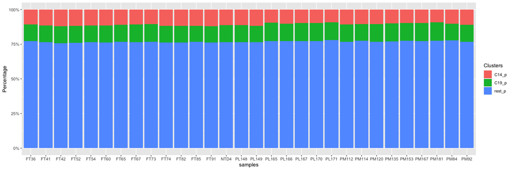

```r
all_colsums <- cbind(colsums_roblab, colsums_c14, colsums_c19)
colnames(all_colsums) <- c("Total", "C14MC", "C19MC")

all_colsums_C19 <- all_colsums %>%
  rownames_to_column(var="samples")  %>%
  mutate(Clusters = "C19_p")


all_colsums_C14 <- all_colsums %>%
  rownames_to_column(var="samples")  %>%
  mutate(Clusters = "C14_p")

all_colsums_total <- all_colsums %>%
   rownames_to_column(var="samples")  %>%
   mutate(Clusters = "rest_p")


all_colsums_up <- bind_rows (all_colsums_C19 ,all_colsums_C14,all_colsums_total)


all_colsums_up <- all_colsums_up %>%
  mutate(Percentage = case_when(
    Clusters == "C19_p" ~ C19MC*100/Total,
     Clusters =="C14_p" ~ C14MC*100/Total,
     Clusters == "rest_p" ~ (Total-C14MC-C19MC)*100/Total))


all_colsums_up %>%
  ggplot( aes( x = samples, y = Percentage, fill = Clusters )) +
    geom_bar(position="fill", stat="identity")+
    scale_y_continuous(labels = scales::percent_format())
```

**Let’s plot all the miRNAs within each cluster by trimester and also by sex**

However, now that we have the precursor, all our mature miRNAs will be grouped into one miRNA. And we can’t just add a -3p and -5p to the ends of the precursors, because some miRNAs don’t have a 3p or 5p version (they just have the one version)

**Join the precursors to the mature miRNA names**

You’ll see that when you try to join, you don’t get any matches, but when you view the df and search, the miRNAs match - can you figure out why the df returned has no matches?

**Fix the error on why the dfs aren’t joining**  
*Hint: Look at the spelling of the miRNAs carefully. And it’s a new function that I’ve introduced in this script somewhere above*

```r
eDat_up <-  eDat %>%
  rownames_to_column(var = "pre:miRNA")

pre_mature <-eDat_up %>%
  select ("pre:miRNA") %>%
   separate("pre:miRNA", c("precursor", "miRNA"), ":")

pre_mature$precursor <-  str_replace_all(pre_mature$precursor   , pattern = "mir", replacement = "miR")

#C19 cluster
c19_mirs$precursor  <- str_replace_all(c19_mirs$precursor   , pattern = "mir", replacement = "miR")

c19_mirs_joined <- c19_mirs %>%
    left_join(pre_mature, by = "precursor")  %>%
    pivot_longer(cols = -c("miRNA", "precursor"),names_to = "Case_ID", values_to = "Reads")

#C14 cluster

c14_mirs$precursor  <- str_replace_all(c14_mirs$precursor   , pattern = "mir", replacement = "miR")

c14_mirs_joined <- c14_mirs %>%
    left_join(pre_mature, by = "precursor")  %>%
    pivot_longer(cols = -c("miRNA", "precursor"),names_to = "Case_ID", values_to = "Reads")
```

**Plot the C14MC and C19MC clusters by trimester/sex and facet by miRNA**

```r
trimester_sex <- eNorm_plot %>%
  select(miRNA, Trimester, Sex)

c19_mirs_joined_eNorm <- c19_mirs_joined %>%
  left_join (trimester_sex, by = "miRNA")

c19_mirs_joined<- c19_mirs_joined %>%
  left_join (mDat, by = "Case_ID")  #when combined with the timester_sex  df I got NA

c14_mirs_joined <- c14_mirs_joined %>%
  left_join (mDat, by = "Case_ID")

c19_mirs_joined %>%
  dplyr::count(Trimester = NA)
```

```
## # A tibble: 1 × 2
##   Trimester     n
##   <lgl>     <int>
## 1 NA         2910
```

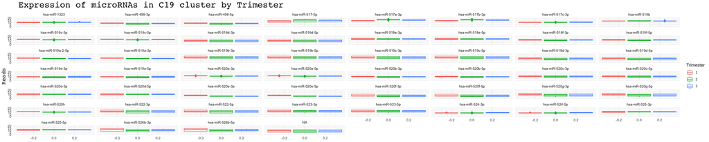

```r
c19_mirs_joined%>%
  # filter (!is.na(c19_mirs_joined$miRNA)) %>% #filtering NA that I got from trimester_sex df
  ggplot (aes( y = Reads, color = Trimester))+
  geom_boxplot() +
  my_theme +
  scale_fill_manual(colpal$Trimester) +
  coord_cartesian(y = c(0,20))+
  facet_wrap(~miRNA) +
  labs(title = " Expression of microRNAs in C19 cluster by Trimester")
```

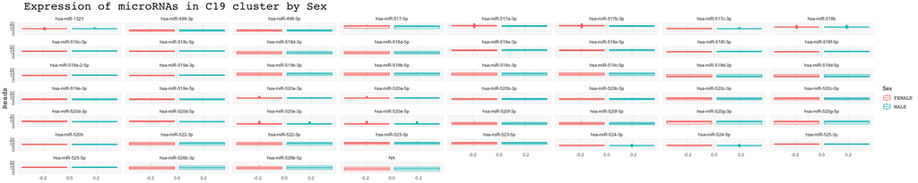

```r
c19_mirs_joined%>%
  ggplot (aes( y = Reads, color = Sex))+
  geom_boxplot() +
  my_theme +
  scale_fill_manual(colpal$Sex) +
  coord_cartesian(y = c(0,20))+
  facet_wrap(~miRNA) +
  labs(title = " Expression of microRNAs in C19 cluster by Sex")
```

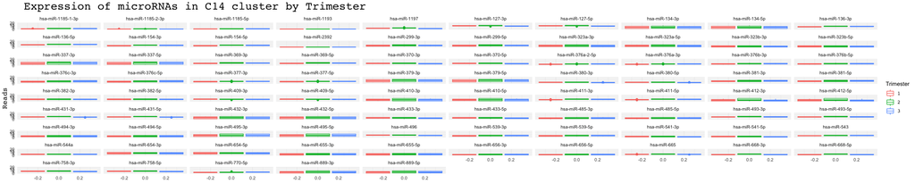

```r
c14_mirs_joined%>%
  ggplot (aes( y = Reads, color = Trimester))+
  geom_boxplot() +
  my_theme +
  scale_fill_manual(colpal$Trimester) +
  coord_cartesian(y = c(0,20))+
  facet_wrap(~miRNA) +
  labs(title = " Expression of microRNAs in C14 cluster by Trimester")
```

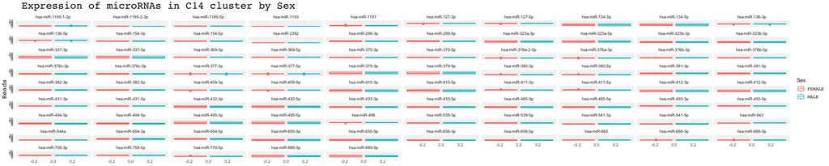

```r
c14_mirs_joined%>%
  ggplot (aes( y = Reads, color = Sex))+
  geom_boxplot() +
  my_theme +
  scale_fill_manual(colpal$Sex) +
  coord_cartesian(y = c(0,20))+
  facet_wrap(~miRNA) +
  labs(title = " Expression of microRNAs in C14 cluster by Sex")
```

> You’re done with your project!